# Heli-attack times

MichaelStorey

22 October 2019

Set the variables for grid size and heli speeds

```r
#define the heli speeds in kmh
all_empty_kmh<- 148
full_ascend_kmh<-74
full_level_kmh<-148 #same as full descending

#point grid size for analysis in metres
point_grid_size<-2500

#how many metres should each line (that will be drawn between a point and a reservoir) be samples
line_sample_point_dist<-100

#choice of whether to include new dams or not. Put 0 to not include (only current reservoirs),put 1 to include (current reservois plus new dams)
include_new_dams<- 0

#output path for point and line shapefiles.
#Remember slashes need to be opposite way than usual for r.  e.g "D:/TEMP/"
output_path<- "D:/TEMP/"

#Paths to the necassary files,(make sure these are pointing to the right place, remember R likes slashes opposite in path names)
dem<-"D:/MS/Projects/HeliAttack_travel_times/data/DEM_SE_Tas_mosaic.tif"
water_poly_full_path<-"D:/MS/Projects/HeliAttack_travel_times/data/reservoir.shp"
new_dams_full_path<-"D:/MS/Projects/HeliAttack_travel_times/data/potential_dam_locations.shp"
```

Load shapefiles Transform coordinate reference system (CRS),and define the variable. Create a point grid across region (ie encompassing the reservoirs of interest). Plot grid points black and water in blue

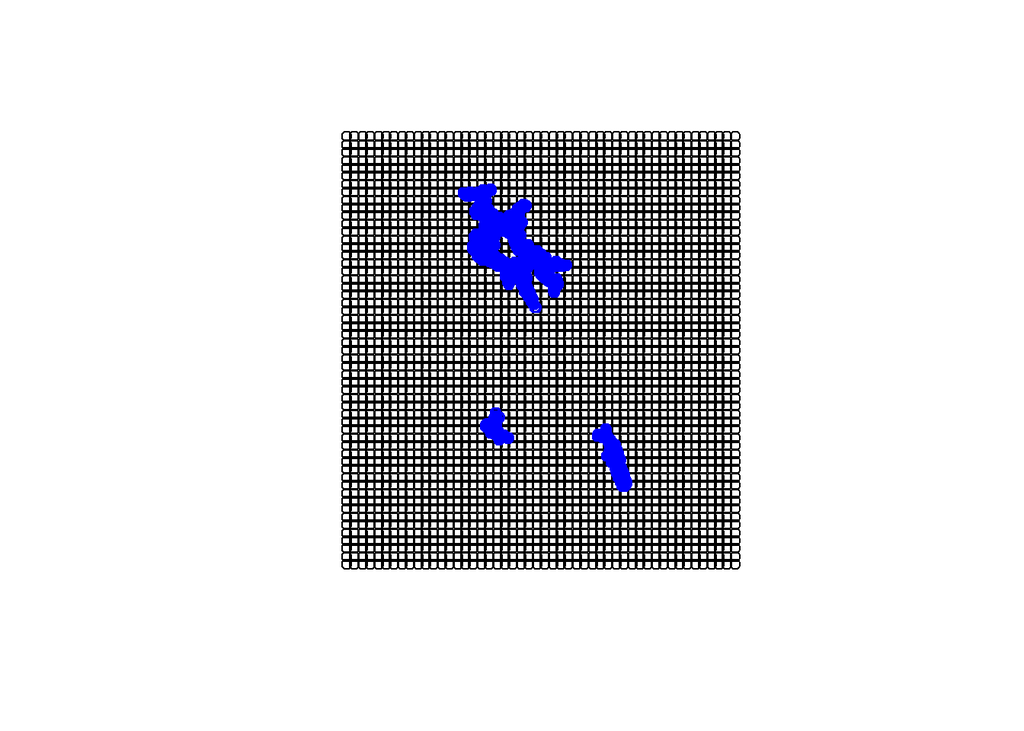

```r
#load and project shapefiles

water_poly<-st_read(water_poly_full_path,quiet=TRUE) %>% st_transform(3111,quiet=TRUE) %>% filter(NAME == "UPPER YARRA RESERVOIR" | NAME == "THOMSON DAM" | NAME == "LAKE EILDON" )

new_dams<-st_read(new_dams_full_path,quiet=TRUE)

st_crs(new_dams)<-3111
point_grid<- water_poly %>% st_make_grid(point_grid_size,what='centers') %>% st_as_sf()
water_points<-st_cast(water_poly,"POINT")

#test to see if new dams included based on variable value entered above
if(include_new_dams == 1){water_points<-st_union(water_points,new_dams) %>% st_cast("POINT")}


#plots
plot(st_geometry(point_grid))
plot(st_geometry(water_points),col='blue',add=TRUE)
```

Draw a line from every point in grid to its closest water source. Plot grid points black, lines brown and water in blue

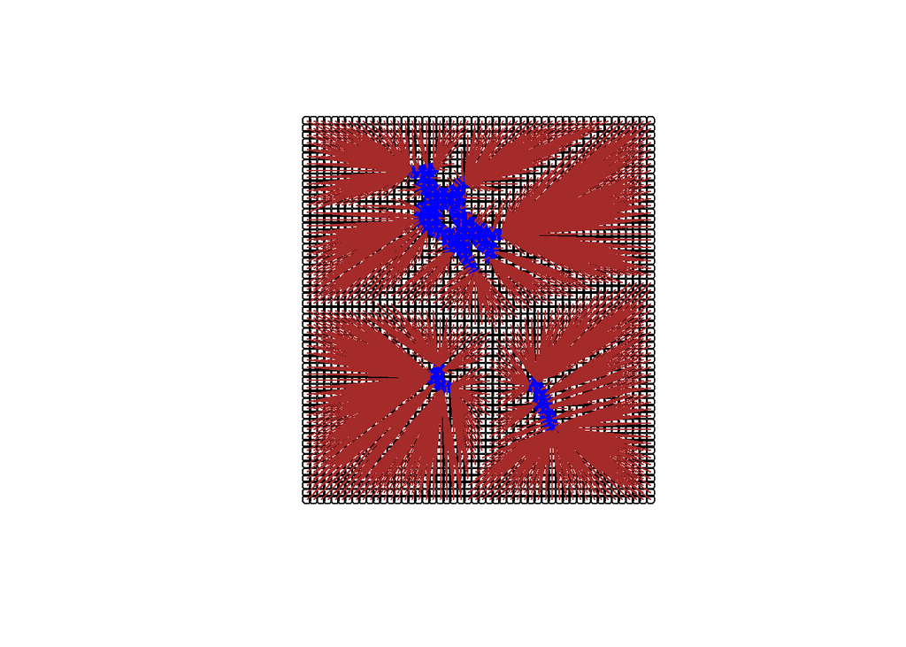

```r
#draw lines from every grid point to nearest water point
nn<-nngeo::st_nn(point_grid,water_points,k=1,progress = FALSE)
near_lines<-nngeo::st_connect(point_grid,water_points,k=1,progress = FALSE)
near_lines<-st_as_sf(near_lines)
near_lines$line_id<-seq.int(nrow(near_lines))

water_points$wp_id<-seq.int(nrow(water_points))
point_grid<-st_join(point_grid,water_points,join=st_nearest_feature)
near_lines$wp_id<-point_grid$wp_id

plot(st_geometry(point_grid))
plot(st_geometry(water_points),col='blue',add=TRUE)
plot(st_geometry(near_lines),col="brown",add=TRUE)
```

For every line from point grid to water, densify line (make vertice every 100 metres) and turn vertices into points (transferring line id to new point feature class)

Sample the DEM for every line vertex point, and select the point with the maximum elevation.

Also sample DEM for elevation of start point (where fire would be) and end point (water point)

Calculate the difference in elevation between start, end, and max elevation

Plots now have max dem point in red

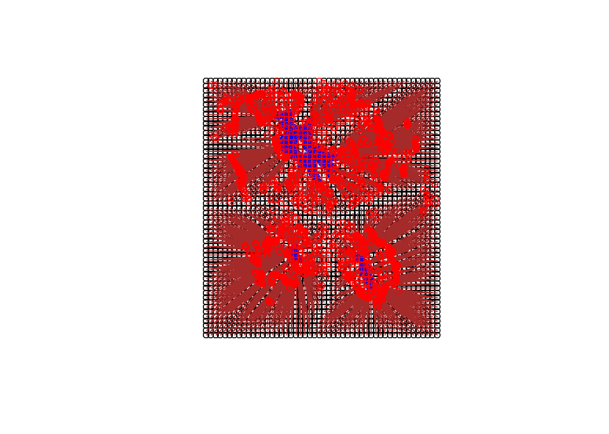

```r
near_lines_dense<- near_lines%>% smoothr::densify(max_distance=line_sample_point_dist)
near_lines_vertices<-st_cast(near_lines_dense,"POINT",do_split = TRUE,warn = FALSE)

#sample dem
raster_dem<-raster::raster(dem)
water_points$dem_wp<-raster::extract(raster_dem,st_transform(water_points,4326))
point_grid$dem_start<-raster::extract(raster_dem,st_transform(point_grid,4326))
near_lines$dem_start<-point_grid$dem_start


near_lines_vertices$dem_path<-raster::extract(raster_dem,st_transform(near_lines_vertices,4326,quiet=TRUE))
max_dem_vertice<-near_lines_vertices %>% group_by(line_id) %>% filter(dem_path==max(dem_path)) %>% mutate(n=n()) %>% mutate(positionInCategory = 1:n()) %>% filter(positionInCategory == 1)
near_lines$peak_dem<-max_dem_vertice$dem_path

#join  height of water point to lines
d<-data.frame(water_points %>% select(wp_id,dem_wp)) %>% select(-geometry)
near_lines<- near_lines %>% left_join(d,by="wp_id")

#calculate height differences
near_lines$st_peak_diff<-near_lines$peak_dem- near_lines$dem_start
near_lines$wp_peak_diff<-near_lines$peak_dem- near_lines$dem_wp

plot(st_geometry(point_grid))
plot(st_geometry(water_points),col='blue',add=TRUE)
plot(st_geometry(near_lines),add=TRUE,col='brown')
plot(st_geometry(max_dem_vertice),add=TRUE,col = 'red')
```

Calculate the distances between start to high dem point, and high dem point to end (water)

Using distances, height differences and speeds (all_empty_kmh<-148,full_ascend_kmh<-74,full_level_kmh<-148) to calculate time on different segments of line. At the moment this assumes heli ascends and descends vertically (not on an angle)

```r
#get distance between high point and start and end points
high_point_to_wp<-st_distance(max_dem_vertice,water_points)
near_lines$peak_to_wp<-as.numeric(apply(high_point_to_wp, 1, FUN=min))
near_lines$dist<-as.numeric(st_length(near_lines))
near_lines$peak_to_start<-near_lines$dist - near_lines$peak_to_wp

#calculate slope
near_lines$slp_wp_dist<-sqrt((near_lines$wp_peak_diff^2)+(near_lines$peak_to_wp^2))
near_lines$slp_start_dist<-sqrt((near_lines$st_peak_diff^2)+(near_lines$peak_to_start^2))

#calculate times
near_lines <- near_lines %>% mutate(time_full_ascend = (wp_peak_diff/1000)/full_ascend_kmh) %>%
  mutate(time_full_level = (dist/1000)/full_level_kmh) %>%
  mutate(time_full_descend = (st_peak_diff/1000)/full_level_kmh) %>%
  mutate(time_empty_ascend = (st_peak_diff/1000)/all_empty_kmh) %>%
  mutate(time_empty_level = (dist/1000)/all_empty_kmh) %>%
  mutate(time_empty_descend = (wp_peak_diff/1000)/all_empty_kmh) %>%
  mutate(total_time = round((time_full_ascend + time_full_level +time_full_descend +
           time_empty_ascend + time_empty_level + time_empty_descend)*60),1)

point_grid$total_time<-near_lines$total_time

#calculate times using pythagoras (ie assuming heli flies on angles over)
near_lines <- near_lines %>% mutate(time_full_ascend_slope = (slp_wp_dist/1000)/full_ascend_kmh) %>%
  mutate(time_full_descend_slope = (slp_start_dist/1000)/full_level_kmh) %>%
  mutate(time_empty_ascend_slope = (slp_start_dist/1000)/all_empty_kmh) %>%
  mutate(time_empty_descend_slope = (slp_wp_dist/1000)/all_empty_kmh) %>%
  mutate(total_time_slope = round((time_full_ascend_slope +time_full_descend_slope +
           time_empty_ascend_slope + time_empty_descend_slope)*60),1)

point_grid$total_time<-near_lines$total_time
point_grid$total_time_slope<-near_lines$total_time_slope

st_write(point_grid, paste0(output_path, "/point_grid.shp"), delete_layer = TRUE)
```

```
## Deleting layer `point_grid' using driver `ESRI Shapefile'
## Writing layer `point_grid' to data source `D:/TEMP//point_grid.shp' using driver `ESRI Shapefile'
## Writing 2750 features with 5 fields and geometry type Point.
```

```r
st_write(near_lines, paste0(output_path, "/near_lines.shp"), delete_layer = TRUE)
```

```
## Deleting layer `near_lines' using driver `ESRI Shapefile'
## Writing layer `near_lines' to data source `D:/TEMP//near_lines.shp' using driver `ESRI Shapefile'
## Writing 2750 features with 25 fields and geometry type Line String.
```

```r
#st_write(max_dem_vertice, paste0("D:/TEMP/", "max_dem.shp"), delete_layer = TRUE)
```

Interactive map of time to closest reservoir (in minutes). Click on a point to see the minutes This map is assuming helicopters ascend and descend vertically, and fly horizontally in between

```r
#distances
point_grid_wgs<-st_transform(point_grid,4326) %>% filter(total_time > 0) %>% as("Spatial")
qpal<- colorNumeric(palette = "YlOrBr",domain = seq(50))

map<-leaflet(point_grid_wgs) %>%addProviderTiles(providers$OpenStreetMap.BlackAndWhite) %>% addCircleMarkers(color = ~qpal(total_time), popup=~htmlEscape(total_time), radius=10, fillOpacity = 1) %>% addPolygons(data=as(st_transform(water_poly,4326),"Spatial"))%>%
  addLegend("bottomright", pal = qpal, values = ~total_time,title = "time in minutes",opacity = 1)# %>%
  #addCircleMarkers(data=as(st_transform(new_dams,4326),"Spatial"),color = "blue", radius=10, fillOpacity = 1)
map
```

[interactive chart not shown]

This map is assuming helicopters fly on angles over peaks

```r
#distances
point_grid_wgs<-st_transform(point_grid,4326) %>% filter(total_time_slope > 0) %>% as("Spatial")
qpal<- colorNumeric(palette = "YlOrBr",domain = seq(50))

map<-leaflet(point_grid_wgs) %>%addProviderTiles(providers$OpenStreetMap.BlackAndWhite) %>% addCircleMarkers(color = ~qpal(total_time_slope), popup=~htmlEscape(total_time_slope), radius=10, fillOpacity = 1) %>% addPolygons(data=as(st_transform(water_poly,4326),"Spatial"))%>%
  addLegend("bottomright", pal = qpal, values = ~total_time_slope,title = "time in minutes",opacity = 1)# %>%
  #addCircleMarkers(data=as(st_transform(new_dams,4326),"Spatial"),color = "blue", radius=10, fillOpacity = 1)
map
```

[interactive chart not shown]